# MPDW 5

# Analisis Sisaan

Model terbaik hasil identifikasi kemudian dicek asumsi sisaannya. Sisaan model ARIMA harus memenuhi asumsi normalitas, kebebasan sisaan, dan kehomogenan ragam. Diagnostik model dilakukan secara eksplorasi dan uji formal.

## Eksplorasi Sisaan

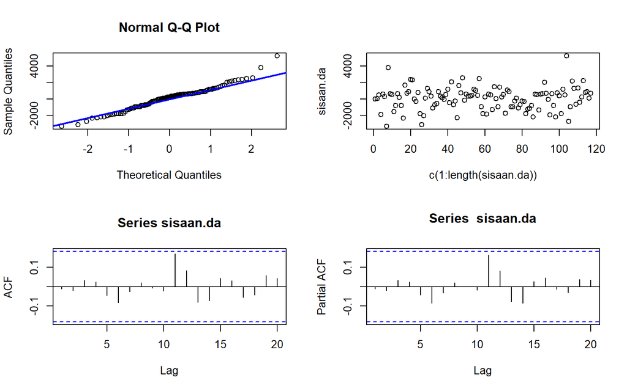

```r
#Eksplorasi
sisaan.da <- model4.da$residuals
par(mfrow=c(2,2))
qqnorm(sisaan.da)
qqline(sisaan.da, col = "blue", lwd = 2)
plot(c(1:length(sisaan.da)),sisaan.da)
acf(sisaan.da)
pacf(sisaan.da)
```

```r
par(mfrow = c(1,1))
```

## Uji Formal

### 1. Sisaan Menyebar Normal

Selain dengan eksplorasi, asumsi tersebut dapat diuji menggunakan uji formal. Pada tahapan ini uji formal yang digunakan untuk normalitas adalah uji Kolmogorov-Smirnov (KS) dan Jarque Bera Test. Hipotesis yang diuji adalah sebagai berikut.

$H_0$ : Sisaan menyebar normal

$H_1$ : Sisaan tidak menyebar normal

```r
ks.test(sisaan.da,"pnorm")  #tolak H0 -> sisaan tidak menyebar normal
```

```
##
##  Asymptotic one-sample Kolmogorov-Smirnov test
##
## data:  sisaan.da
## D = 0.5812, p-value < 2.2e-16
## alternative hypothesis: two-sided
```

```r
jarque.bera.test(sisaan.da) #tolak H0 -> sisaan tidak menyebar normal
```

```
##
##  Jarque Bera Test
##
## data:  sisaan.da
## X-squared = 7.9023, df = 2, p-value = 0.01923
```

Berdasarkan kedua uji tersebut, didapat *p-value* yang kurang dari taraf nyata 5% sehingga tolak $H_0$ dan menandakan bahwa **sisaan tidak menyebar normal.** Hal ini sesuai dengan hasil eksplorasi menggunakan plot kuantil-kuantil normal.

### 2. Sisaan Saling Bebas/Tidak Ada Autokorelasi

Selanjutnya akan dilakukan uji formal untuk kebebasan sisaan menggunakan uji Ljung-Box. Hipotesis yang digunakan adalah sebagai berikut.

$H_0$ : Sisaan saling bebas

$H_1$ : Sisaan tidak tidak saling bebas

```r
Box.test(sisaan.da, type = "Ljung")  #tak tolak H0 -> sisaan saling bebas
```

```
##
##  Box-Ljung test
##
## data:  sisaan.da
## X-squared = 0.018326, df = 1, p-value = 0.8923
```